# Post 6: Analyzing data + Exploring Interactivity

Team Rreproduce

2022-11-18

This week we worked on combining two datasets and analyzing the patterns of several parameters and their relationship with others. Some of them will be used for answering our research questions.

First, we explore the influence of state crime rate on the migration status.

```r
##Organizing datas
library(tidyverse)
leave <-read_csv(here::here("dataset", "leave.csv"))
movein <- read_csv(here::here("dataset", "movein.csv"))
early <- read_csv(here::here("dataset","00-07CrimeAvg.csv"))
later <- read_csv(here::here("dataset","10-17CrimeAvg.csv"))
early<-early %>% arrange(meanRobbery)
early1<- early %>% arrange(meanBurglary)
later<-later %>% arrange(meanRobbery)
later1<-later %>% arrange(meanBurglary)
```

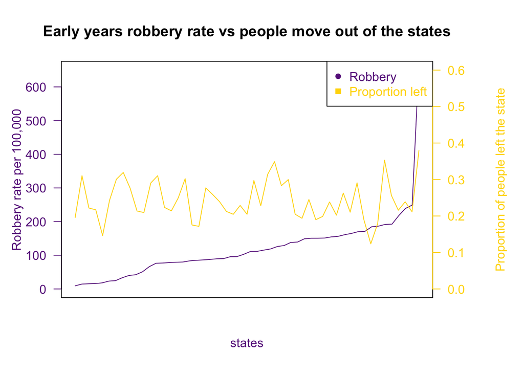

```r
par(mar=c(5, 4, 4, 6) + 0.1)
plot(early$meanRobbery, pch=16, axes=FALSE, ylim=c(0,650), xlab="", ylab="",
   type="l",col="darkorchid4", main="Early years robbery rate vs people move out of the states")
axis(2, ylim=c(0,1),col="darkorchid4",col.axis="darkorchid4",las=1)  ## las=1 makes horizontal labels
mtext("Robbery rate per 100,000",side=2,col="darkorchid4",line=2.5)
box()
par(new=TRUE)
plot(leave$proportion, pch=15,  xlab="", ylab="", ylim=c(0,0.6),
    axes=FALSE, type="l", col="gold1")
mtext("Proportion of people left the state",side=4,col="gold1",line=4)
axis(4, ylim=c(0,7000), col="gold1",col.axis="gold1",las=1)
mtext("states",side=1,col="darkorchid4",line=2.5)
legend("topright",legend=c("Robbery","Proportion left"),
  text.col=c("darkorchid4","gold1"),pch=c(16,15),col=c("darkorchid4","gold1"))
```

This graph demonstrates the relationship between the average robbery rate in each state (from 2000-2007) vs. the proportion of people who left that state (ends up in other states in ~2017). No significant relationship is found.

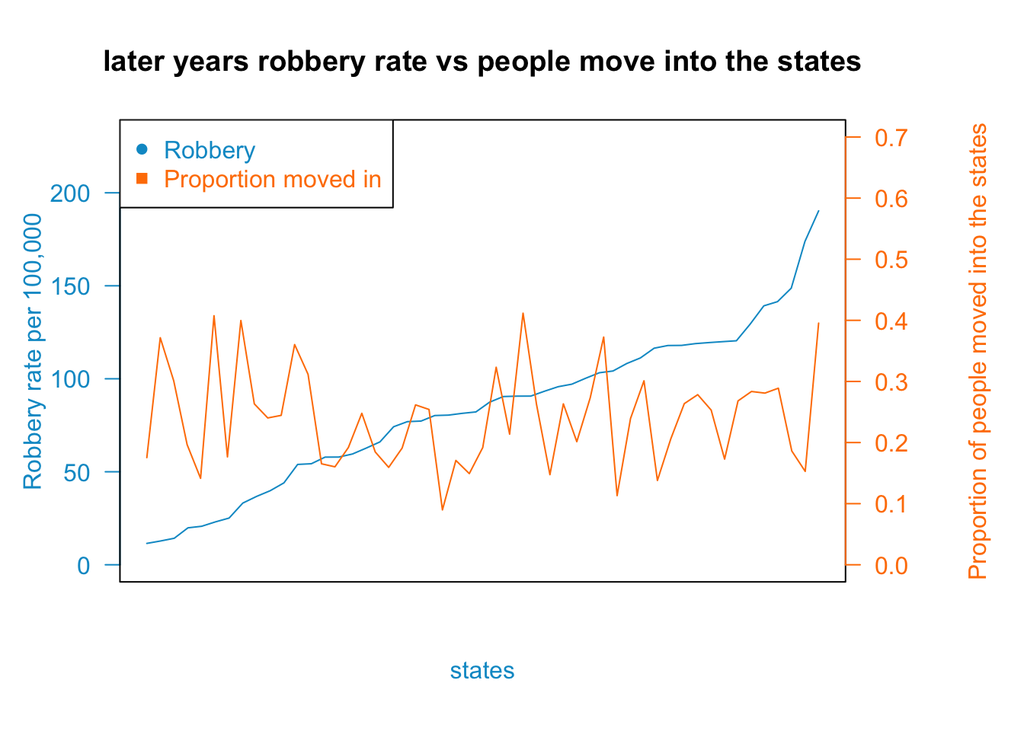

```r
par(mar=c(5, 4, 4, 6) + 0.1)
plot(later$meanRobbery, pch=16, axes=FALSE, ylim=c(0,230), xlab="", ylab="",
   type="l",col="deepskyblue3", main="later years robbery rate vs people move into the states")
axis(2, ylim=c(0,1),col="deepskyblue3",col.axis="deepskyblue3",las=1)  ## las=1 makes horizontal labels
mtext("Robbery rate per 100,000",side=2,col="deepskyblue3",line=2.5)
box()
par(new=TRUE)
plot(movein$proportion, pch=15,  xlab="", ylab="", ylim=c(0,0.7),
    axes=FALSE, type="l", col="darkorange1")
mtext("Proportion of people moved into the states",side=4,col="darkorange1",line=4)
axis(4, ylim=c(0,7000), col="darkorange1",col.axis="darkorange1",las=1)
mtext("states",side=1,col="deepskyblue3",line=2.5)
legend("topleft",legend=c("Robbery","Proportion moved in"),
  text.col=c("deepskyblue3","darkorange1"),pch=c(16,15),col=c("deepskyblue3","darkorange1"))
```

This graph demonstrates the relationship between the average robbery rate in each state (from 2010-2017) vs. the proportion of people who are attracted to immigrate to that state (in ~2017). No significant relationship is found.

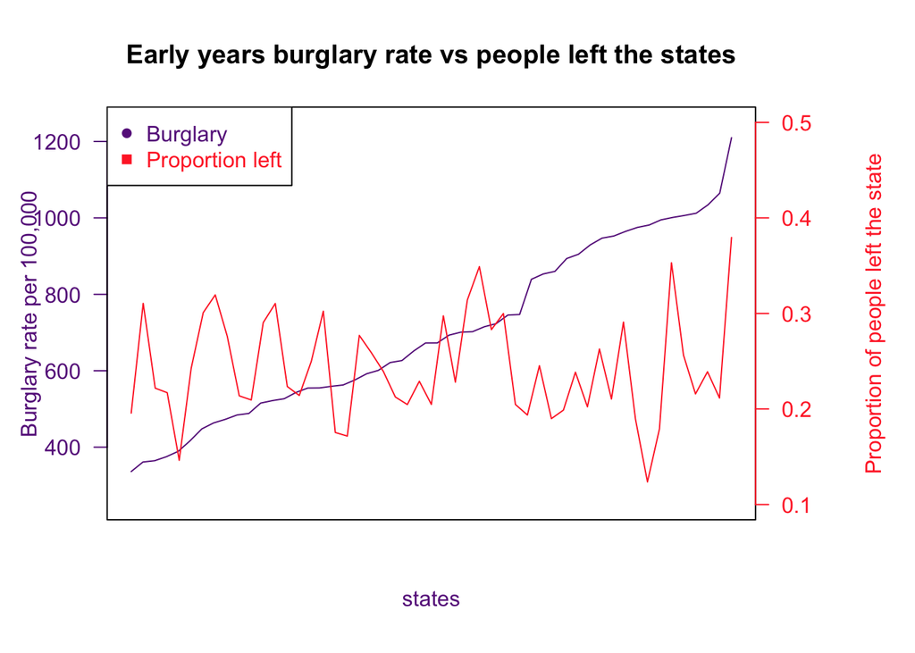

```r
# for early/ left / Burglary
par(mar=c(5, 4, 4, 6) + 0.1)
plot(early1$meanBurglary, pch=16, axes=FALSE, ylim=c(250,1250), xlab="", ylab="",
   type="l",col="darkorchid4", main="Early years burglary rate vs people left the states")
axis(2, ylim=c(0,1),col="darkorchid4",col.axis="darkorchid4",las=1)  ## las=1 makes horizontal labels
mtext("Burglary rate per 100,000",side=2,col="darkorchid4",line=2.5)
box()
par(new=TRUE)
plot(leave$proportion, pch=15,  xlab="", ylab="", ylim=c(0.1,0.5),
    axes=FALSE, type="l", col="firebrick1")
mtext("Proportion of people left the state",side=4,col="firebrick1",line=4)
axis(4, ylim=c(0,7000), col="firebrick1",col.axis="firebrick1",las=1)
mtext("states",side=1,col="darkorchid4",line=2.5)
legend("topleft",legend=c("Burglary","Proportion left"),
  text.col=c("darkorchid4","firebrick1"),pch=c(16,15),col=c("darkorchid4","firebrick1"))
```

This graph demonstrates the relationship between the average burglary rate in each state (from 2000-2007) vs. the proportion of people who left that state (ends up in other states in ~2017). No significant relationship is found.

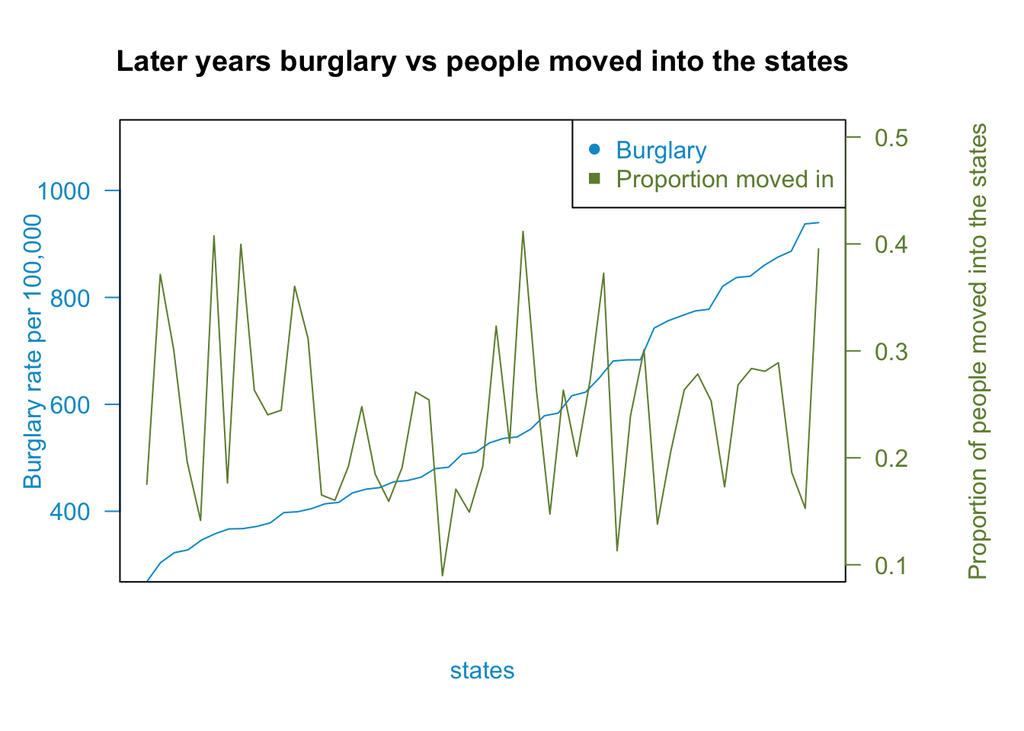

```r
# For later movein / Burglary
par(mar=c(5, 4, 4, 6) + 0.1)
plot(later1$meanBurglary, pch=16, axes=FALSE, ylim=c(300,1100), xlab="", ylab="",
   type="l",col="deepskyblue3", main="Later years burglary vs people moved into the states")
axis(2, ylim=c(0,1),col="deepskyblue3",col.axis="deepskyblue3",las=1)  ## las=1 makes horizontal labels
mtext("Burglary rate per 100,000",side=2,line=2.5,col = 'deepskyblue3')
box()
par(new=TRUE)
plot(movein$proportion, pch=15,  xlab="", ylab="", ylim=c(0.1,0.5),
    axes=FALSE, type="l", col="darkolivegreen4")
mtext("Proportion of people moved into the states",side=4,col="darkolivegreen4",line=4)
axis(4, ylim=c(0,7000), col="darkolivegreen4",col.axis="darkolivegreen4",las=1)
mtext("states",side=1,col="deepskyblue3",line=2.5)
legend("topright",legend=c("Burglary","Proportion moved in"),
  text.col=c("deepskyblue3","darkolivegreen4"),pch=c(16,15),col=c("deepskyblue3","darkolivegreen4"))
```

This graph demonstrates the relationship between the average burglary rate in each state (from 2010-2017) vs. the proportion of people who are attracted to immigrate to that state (in ~2017). No significant relationship is found.